# Final Model

```r
library(tidyverse)
library(readxl)
library(randomForest)
require(caTools)
library(MASS)
library(caret)
library(class)
library(BBmisc)
```

```r
library(ggplot2)
```

# Goal

We will employ a variety of statistical learning techniques to understand key features of the data and the relationship between certain predictor variables and institutional allocation to alumni engagement in higher education. The best-performing models will then be used for prediction purposes and extrapolated to the broader set of colleges within the United States to arrive at a TAM estimate.

# Data Cleaning and Variable Selection

```r
# select variables and convert to factors
df <- read_excel("data/Alumni-Engagement-Market-Research-Master-List.xlsx")
df <- df %>% dplyr::select(Rank, Q1, Q2, Q3, Q4, Q5, Q6, Q42, Q43, Q44, Q45)
df <- df[-1,]
df <- df %>% mutate_all(funs(factor(.)))
df
```

```
## # A tibble: 50 x 11
##    Rank   Q1     Q2     Q3     Q4    Q5    Q6     Q42   Q43     Q44   Q45
##    <fct>  <fct>  <fct>  <fct>  <fct> <fct> <fct>  <fct> <fct>   <fct> <fct>
##  1 Exist… Public 10,00… < $50… 7 - 9 < 10% Black… <NA>  1% - 3% $80,… Up
##  2 Exist… Public 10,00… < $50… 1 - 3 10% … None   <NA>  Spendi… < $2… Down
##  3 Exist… Priva… 50,00… $1B -… 4 - 6 40% … None   30% … Spendi… $20,… Down
##  4 Exist… Priva… < 10,… $1B -… 4 - 6 30% … Black… <NA>  1% - 3% $40,… Stay…
##  5 Exist… Public 10,00… < $50… 7 - 9 10% … Other  30% … 1% - 3% < $2… Stay…
##  6 Exist… Public 20,00… < $50… 7 - 9 10% … Hands… 10% … Spendi… $20,… Stay…
##  7 Exist… Priva… < 10,… < $50… 1 - 3 10% … Black… 10% … Spendi… $60,… Stay…
##  8 Exist… Public < 10,… < $50… 7 - 9 10% … None   <NA>  Spendi… < $2… Stay…
##  9 Exist… Public 10,00… < $50… 4 - 6 20% … Black… 10% … 5% - 7% $20,… Stay…
## 10 Exist… Public 20,00… $500M… 10+   30% … Black… <NA>  5% - 7% $60,… Up
## # … with 40 more rows
```

```r
# remove non-collectible variables for prediction purposes
sub_data <- df %>%
  dplyr::select(Q44, Rank, Q1, Q2, Q3, Q4)
sub_data <- na.omit(sub_data) #remove NAs
sub_data
```

```
## # A tibble: 38 x 6
##    Q44                Rank     Q1      Q2              Q3          Q4
##    <fct>              <fct>    <fct>   <fct>           <fct>       <fct>
##  1 $80,000 - $100,000 Existing Public  10,000 - 20,000 < $500M     7 - 9
##  2 < $20,000          Existing Public  10,000 - 20,000 < $500M     1 - 3
##  3 $20,000 - $40,000  Existing Private 50,000+         $1B - $5B   4 - 6
##  4 $40,000 - $60,000  Existing Private < 10,000        $1B - $5B   4 - 6
##  5 < $20,000          Existing Public  10,000 - 20,000 < $500M     7 - 9
##  6 $20,000 - $40,000  Existing Public  20,000 - 30,000 < $500M     7 - 9
##  7 $60,000 - $80,000  Existing Private < 10,000        < $500M     1 - 3
##  8 < $20,000          Existing Public  < 10,000        < $500M     7 - 9
##  9 $20,000 - $40,000  Existing Public  10,000 - 20,000 < $500M     4 - 6
## 10 $60,000 - $80,000  Existing Public  20,000 - 30,000 $500M - $1B 10+
## # … with 28 more rows
```

```r
# reformat data into quantiative variables
data <- sub_data %>% mutate(spending = ifelse(Q44 == "$80,000 - $100,000", 90000,
                                      ifelse(Q44 == "$60,000 - $80,000", 70000,
                                             ifelse(Q44 == "$40,000 - $60,000", 50000,
                                                    ifelse(Q44 == "$20,000 - $40,000", 30000,
                                                           10000))))) %>%
  mutate(numRank = ifelse(Rank == "1-20", 10,
                          ifelse(Rank == "21-40", 30,
                                 ifelse(Rank == "41-60", 50,
                                        ifelse(Rank == "61-80", 70,
                                               ifelse(Rank == "81-100", 90,
                                                     150)))))) %>%
  mutate(pop_size = ifelse(Q2 == "< 10,000", 5000,
                           ifelse(Q2 == "10,000 - 20,000", 15000,
                                  ifelse(Q2 == "20,000 - 30,000", 250000,
                                         ifelse(Q3 == "30,000 - 40,000", 35000,
                                                ifelse(Q3 == "40,000 - 50,000", 45000,
                                                       75000)))))) %>%
  mutate(endowment = ifelse(Q3 == "< $500M", 250,
                            ifelse(Q3 == "$500M - $1B", 750,
                                   ifelse(Q3 == "$1B - $5B", 2500,
                                          ifelse(Q3 == "$5B - $10B", 7500,
                                                 ifelse(Q3 == "$10B - $15B", 12500,
                                                        25000)))))) %>%
  mutate(schools = ifelse(Q4 == "1 - 3", 2,
                          ifelse(Q4 == "4 - 6", 5,
                                 ifelse(Q4 == "7 - 9", 8,
                                        11)))) %>%
  dplyr::select(spending, numRank, pop_size, endowment, schools)

data
```

```
## # A tibble: 38 x 5
##    spending numRank pop_size endowment schools
##       <dbl>   <dbl>    <dbl>     <dbl>   <dbl>
##  1    90000     150    15000       250       8
##  2    10000     150    15000       250       2
##  3    30000     150    75000      2500       5
##  4    50000     150     5000      2500       5
##  5    10000     150    15000       250       8
##  6    30000     150   250000       250       8
##  7    70000     150     5000       250       2
##  8    10000     150     5000       250       8
##  9    30000     150    15000       250       5
## 10    70000     150   250000       750      11
## # … with 28 more rows
```

# EDA

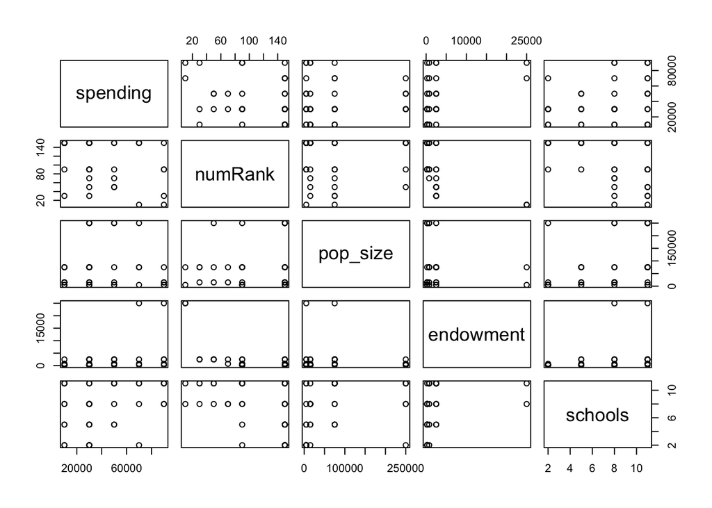

```r
attach(data)
pairs(data)
```

# Models

## Linear Stepwise Regression

```r
full_lm <- lm(spending ~., data = data)
step_lm <- stepAIC(full_lm, direction = "both", trace = FALSE)
summary(step_lm)
```

```
##
## Call:
## lm(formula = spending ~ endowment + schools, data = data)
##
## Residuals:
##    Min     1Q Median     3Q    Max
## -37472 -17155  -2696   9605  51763
##
## Coefficients:
##              Estimate Std. Error t value Pr(>|t|)
## (Intercept) 2.305e+04  9.648e+03   2.389   0.0224 *
## endowment   1.642e+00  7.492e-01   2.191   0.0352 *
## schools     1.847e+03  1.228e+03   1.505   0.1414
## ---
## Signif. codes:  0 '***' 0.001 '**' 0.01 '*' 0.05 '.' 0.1 ' ' 1
##
## Residual standard error: 24370 on 35 degrees of freedom
## Multiple R-squared:  0.2065, Adjusted R-squared:  0.1612
## F-statistic: 4.555 on 2 and 35 DF,  p-value: 0.01745
```

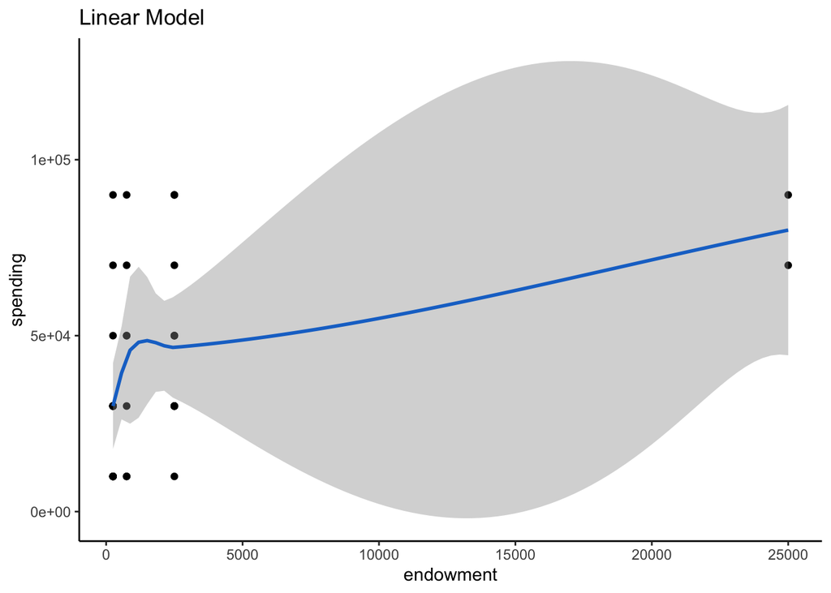

```r
ggplot(data = data, aes(x = endowment, y = spending)) +
  geom_point() +
  stat_smooth(methold = "lm", col = "dodgerblue3") +
  theme(panel.background = element_rect(fill = "white"),
        axis.line.x = element_line(),
        axis.line.y = element_line()) +
  ggtitle("Linear Model")
```

```r
# Train a model with k-fold cross-validation
set.seed(24)
train_control <- trainControl(method = "cv", number = 10)
step_model <- train(spending ~., data = data,
                    method = "leapSeq",
                    tuneGrid = data.frame(nvmax = 1:4),
                    trControl = train_control
                    )
step_model$results
```

```
##   nvmax     RMSE  Rsquared      MAE   RMSESD RsquaredSD     MAESD
## 1     1 23807.84 0.5170825 20955.18 11082.39  0.4222566  9698.566
## 2     2 22640.18 0.6240653 19348.86 10199.76  0.3533817  9149.072
## 3     3 24739.09 0.5711999 21696.54 11866.34  0.3722449 10948.124
## 4     4 24454.74 0.4393289 21153.92 11726.32  0.3702867 10715.408
```

```r
step_model$bestTune
```

```
##   nvmax
## 2     2
```

```r
summary(step_model$finalModel)
```

```
## Subset selection object
## 4 Variables  (and intercept)
##           Forced in Forced out
## numRank       FALSE      FALSE
## pop_size      FALSE      FALSE
## endowment     FALSE      FALSE
## schools       FALSE      FALSE
## 1 subsets of each size up to 2
## Selection Algorithm: 'sequential replacement'
##          numRank pop_size endowment schools
## 1  ( 1 ) " "     " "      "*"       " "
## 2  ( 1 ) " "     " "      "*"       "*"
```

```r
coef(step_model$finalModel, 1)
```

```
##  (Intercept)    endowment
## 36037.832341     1.905725
```

Conducting stepwise regression shows that only `endowment` appears to have a statistically significant relationship with `spending`.

## Logistic Regression

```r
full_logit <- glm(factor(spending, order = TRUE, levels = c(10000, 30000, 50000, 70000, 90000)) ~ .,
                  data = data, family = "binomial")
step_logit <- stepAIC(full_logit, direction = "both", trace = FALSE)
summary(step_logit)
```

```
##
## Call:
## glm(formula = factor(spending, order = TRUE, levels = c(10000,
##     30000, 50000, 70000, 90000)) ~ pop_size + endowment, family = "binomial",
##     data = data)
##
## Deviance Residuals:
##      Min        1Q    Median        3Q       Max
## -2.25188   0.00011   0.40629   0.83396   1.10112
##
## Coefficients:
##               Estimate Std. Error z value Pr(>|z|)
## (Intercept) -4.614e-02  6.027e-01  -0.077    0.939
## pop_size     8.664e-06  6.729e-06   1.288    0.198
## endowment    7.397e-04  5.072e-04   1.458    0.145
##
## (Dispersion parameter for binomial family taken to be 1)
##
##     Null deviance: 41.603  on 37  degrees of freedom
## Residual deviance: 34.944  on 35  degrees of freedom
## AIC: 40.944
##
## Number of Fisher Scoring iterations: 7
```

Neither of the coefficients are particularly meaningful in the final model selected by stepwise selection.

## KNN

```r
norm_data <- cbind(data[,1],as.data.frame(lapply(data[2:5], normalize))) # normalize data for standardization across predictors
set.seed(100)
train_ind <- sample(x = nrow(norm_data), size = 0.75 * nrow(norm_data))
test_ind_neg <- -train_ind
training <- norm_data[train_ind, ]
testing <- norm_data[test_ind_neg, ]
train_labels <- norm_data[train_ind, 1]
spending_pred <- knn(train = training, test = testing, cl = train_labels)
table(spending_pred, testing$spending)
```

```
##
## spending_pred 10000 30000 50000 70000 90000
##         10000     1     0     0     0     0
##         30000     0     6     0     0     0
##         50000     0     0     1     0     0
##         70000     0     0     0     1     0
##         90000     0     0     0     0     1
```

KNN gives us 100% classification accuracy on the testing data set in this instance, but we will perform cross-validation to find a more robust model and choice for `k`.

```r
set.seed(45)
trControl <- trainControl(method = "cv",
                          number = 10)
knn_fit <- train(factor(spending, order = TRUE, levels = c(10000, 30000, 50000, 70000, 90000)) ~ .,
             method = "knn",
             tuneGrid = expand.grid(k = 1:10),
             trControl = trControl,
             metric = "Accuracy",
             data = data)
knn_fit
```

```
## k-Nearest Neighbors
##
## 38 samples
##  4 predictor
##  5 classes: '10000', '30000', '50000', '70000', '90000'
##
## No pre-processing
## Resampling: Cross-Validated (10 fold)
## Summary of sample sizes: 34, 35, 35, 35, 34, 32, ...
## Resampling results across tuning parameters:
##
##   k   Accuracy   Kappa
##    1  0.2833333   0.063907204
##    2  0.2416667  -0.020329670
##    3  0.4416667   0.194615385
##    4  0.3166667   0.079438339
##    5  0.3916667   0.076666667
##    6  0.3250000   0.005555556
##    7  0.3583333   0.067948718
##    8  0.2500000  -0.063003663
##    9  0.2833333  -0.013003663
##   10  0.3333333   0.028888889
##
## Accuracy was used to select the optimal model using the largest value.
## The final value used for the model was k = 3.
```

Classification accuracy approaches 50% with the choice of `k = 3`, which is encouraging given that there are five different response classes.

## Random Forest

```r
rf <- randomForest(factor(spending, order = TRUE, levels = c(10000, 30000, 50000, 70000, 90000)) ~ .,
                   data = data, ntree = 10000)
rf
```

```
##
## Call:
##  randomForest(formula = factor(spending, order = TRUE, levels = c(10000,      30000, 50000, 70000, 90000)) ~ ., data = data, ntree = 10000)
##                Type of random forest: classification
##                      Number of trees: 10000
## No. of variables tried at each split: 2
##
##         OOB estimate of  error rate: 78.95%
## Confusion matrix:
##       10000 30000 50000 70000 90000 class.error
## 10000     2     5     0     0     2   0.7777778
## 30000     6     4     2     0     2   0.7142857
## 50000     0     4     1     1     0   0.8333333
## 70000     1     2     1     0     0   1.0000000
## 90000     2     2     0     0     1   0.8000000
```

The classification accuracy of the random forest algorithm is relatively low.

## Linear Discriminant Analysis

```r
spending.lda <- lda(factor(spending, order = TRUE, levels = c(10000, 30000, 50000, 70000, 90000)) ~., data = data)
lda.pred <- predict(spending.lda)
table(data$spending, lda.pred$class)
```

```
##
##         10000 30000 50000 70000 90000
##   10000     5     3     1     0     0
##   30000     2    11     1     0     0
##   50000     1     4     1     0     0
##   70000     1     2     0     1     0
##   90000     2     1     0     1     1
```

## Quadratic Discriminant Analysis

```r
spending_qda <- qda(spending ~ schools + numRank + pop_size + schools, data = data)
qda_pred <- predict(spending_qda)
table(data$spending, qda_pred$class)
```

```
##
##         10000 30000 50000 70000 90000
##   10000     7     2     0     0     0
##   30000     4     8     0     0     2
##   50000     2     1     2     0     1
##   70000     1     0     1     1     1
##   90000     2     0     0     0     3
```

The confusion matrix looks much better than the ones obtained from Random Forest and Linear Discriminant Analysis. We will perform leave-one-out cross-validation to evaluate the robustness of the model.

```r
spending_qda_cv <- qda(spending ~ schools + numRank + pop_size + schools, CV = TRUE, data = data)
table(data$spending, spending_qda_cv$class)
```

```
##
##         10000 30000 50000 70000 90000
##   10000     5     3     0     0     1
##   30000     4     5     1     1     3
##   50000     2     2     0     1     1
##   70000     1     0     2     0     1
##   90000     2     0     1     0     2
```

# Final Model

The best-performing models were multiple linear regression, KNN, and QDA. We will use each of them in turn to get an estimate for spending at each of the top 385 colleges in the United States as ranked in the U.S. News & World Report rankings. This will serve as the basis for our TAM estimate.

```r
pred_data <- read_excel("data/Final-Data-Collection-Sheet.xlsx")
pred_data <- pred_data %>%
  dplyr::select(Rank, Population_Size, Endowment, Schools) %>%
  rename(numRank = Rank, pop_size = Population_Size, endowment = Endowment, schools = Schools)
head(pred_data <- round(transform(pred_data, endowment = as.double(endowment)), 1))
```

```
##   numRank pop_size endowment schools
## 1       1     8623     25900       5
## 2       2    31120     41900      12
## 3       3    31077     11260      20
## 4       4    11254     18380       5
## 5       5    12974     30310      14
## 6       6    17249     27700       7
```

```r
# impute missing values
library(imputeMissings)
pred_data <- impute(pred_data, method = "randomForest")
head(pred_data)
```

```
##   numRank pop_size endowment schools
## 1       1     8623     25900       5
## 2       2    31120     41900      12
## 3       3    31077     11260      20
## 4       4    11254     18380       5
## 5       5    12974     30310      14
## 6       6    17249     27700       7
```

## Linear Regression Prediction

```r
# Use the stepwise regression model
pred_lm <- predict(step_lm, pred_data)
sum(pred_lm)
```

```
## [1] 16223525
```

## KNN Prediction

```r
# use normalized data from above for training
pred_knn <- predict(knn_fit, newdata = pred_data)
sum(as.numeric(as.character(pred_knn)))
```

```
## [1] 7870000
```

A KNN with k = 3 gives $\$7,870,000$ as an estimate for TAM. While the KNN prediction worked relatively well when cross validation was used earlier, it is very likely that this estimate pretty substantially underestimates the actual market size. This is because the survey data obtained did not have any responses that indicated spending on alumni engagement services exceeding $\$100,000$. This is certainly not the case, but rather is a limitation of the dataset.

## Quadratic Discriminant Analysis Prediction

```r
pred_qda <- predict(spending_qda, newdata = pred_data)
sum(as.numeric(as.character(pred_qda$class)))
```

```
## [1] 19010000
```

# Recommendations

We contend with high confidence that these estimates for the size of the Total Addressable Market (TAM) for alumni engagement services should serve as lower-bound estimates. Limitations from survey data– both due to its anonymous nature and unrepresentativeness of institutions that spend more than $\$100,000$ on alumni engagement software solutions– likely contributed to a downward bias in estimates.